```python
import pylab as pl
from  numpy.random import normal
import numpy as np
import healpy as hp
from scipy  import  signal
from scipy.signal import periodogram

from pylab import cm
cmap = cm.get_cmap('RdYlBu')
cmap.set_under('w')
from __future__ import print_function
from ipywidgets import interact, interactive, fixed, interact_manual
import ipywidgets as widgets
%matplotlib inline
```

```python
from IPython.display import HTML

HTML('''<script>
code_show=true;
function code_toggle() {
 if (code_show){
 $('div.input').hide();
 } else {
 $('div.input').show();
 }
 code_show = !code_show
}
$( document ).ready(code_toggle);
</script>
<form action="javascript:code_toggle()"><input type="submit" value="Click here to toggle on/off the raw code."></form>''')
```

# 1. Summary of latest results

07/25/2019

In [my previous posting](http://giuspugl.github.io/reports/gaindrifts_07062019.html), I've shown that the regression technique wasn't able to track both gain mismatches ( i.e. random fluctuations constant during a given timescale $\tau_g$ ) and gain drifts ( slowly varying drifting signal with a $1/f$ dependence ) if :

- $\tau_g$ was very short ($< 10$ min)
- we high pass filter the data with a low frequency cut-off $f_c = 1 $mHz
- $\sigma_g> 10^{-4} $ ( even for signal only sims ) Our conclusions were: _the longer the timescale $ \tau_g $ and the larger $\sigma_g$ the better are the gain estimates_ .

However, we observed some inconsistency in tracking the gains especially when $\tau_g=1$ min. Moreover, for signal only sims we should be able to track very well the gain estimates **for any value** of $\sigma_g$.

To check whether there was a bug in the gain estimation code I've therefore turned off the gain drifts, high-pass filtered the tod and run the gain estimates and as expected all of them were exactly 1.

I 've also checked the way I filter the data. I use the external `python` module `scipy.signal.filtfilt` and found that's very useful to pad the edges of the timestream with a number of samples proportional to the number of samples at my cutoff frequency, i.e. $f_s/f_c$ , where $f_s=20 $ Hz is the sampling rate.

### Cutoff frequency plays a crucial role

The reason of the inconsistency outlined in the previous postings, is due to the fact that I was filtering the data with a **too low** cut off frequency. As rule of thumbs we should have :

$$ f_c > f_{\tau} = \tau_g^{-1} $$

In facts, both for $\tau_g = 1 $ and $10 $ min we had respectively $f_{\tau} = 16 $ and 1.6 mHz . In the plots below I show the case with $f_c = 50 $ mHz and you can see how nicely we are able to track the gain estimates for both $\tau_g=1$ and 10 min.

Furthermore, this doesn't depend on the amplitude of the gain fluctuations, I've checked even for very small and large values of $\sigma_g$, the case below encode $\sigma_g = 10^{-6} $ (fairly small wrt previous runs).

Finally, we remind that the gain drift has a 1/f dependence ( with $ f_k = 150 $ mHz ) and it has been low pass filtered with $f_{lpf} = 1 $ mHz, so that all the gain fluctuations below the ~ 10 minutes time scale are filtered out.

To summarize : gain drift systematics are now fully parametrized by 5 parameters $(f_k, f_{lpf} , f_c, \tau_g, \sigma_g ) $

### Simulation setups

Drift Parameters:

- $f_c = 50$ mHz
- $ \sigma_g= 10^{-6}$
- $\tau_g = 1, 10 $ min
- the gain drift has a 1/f dependence ( with $ f_k = 150 $ mHz ) and it has been low pass filtered with a cut off freq. of 1 mHz, so that all the gain fluctuations below the ~ 10 minutes time scale are filtered out.

Toast Params:

- Noise simulated :False
- Detector pairs: 2
- T_obs : 1 yr
- sampling freq: 20 Hz
- precession period :96.1803 min
- spin period: 10 min
- HWP : False
- spin angle : 50
- precession angle :45
- MADAM destriper (baseline=60 sec)
- Input maps: Monopole, Dipole, CMB T , Galactic emission @ 110 GHz

The procedure to mitigate gain mismatches is performed on each chunck (related to $\tau$) of time samples $d_{t , t+\tau}$ of a given detector:

1. Apply a high-pass filter to $d_{t , t+\tau} $ with cutoff frequency $f_{c}=50$ mHz
2. Regress $d_{t , t+\tau} $ against signal-only template $T$ and estimate the regression slope $\hat{g}$ as $$ \hat{g} = \frac { T^{t} d } { T^{t} T } $$
3. Mitigate the leakage, dividing $d_{t , t+\tau} $ by $\hat{g}$
4. Estimate maps after mitigation

```python
def bin_gains(tau, fs,obs,  g) :
    sizech = pl.int_( tau *fs)  ; nch =pl.int_(  obs *fs*3600  /sizech)
    gb = pl.zeros(nch)
    for i in range (nch):
        gb[i] =g[slice(i*sizech, (i+1)*sizech)] .mean()
    return gb
```

```
(720,)
```

```
(1, 2)
```

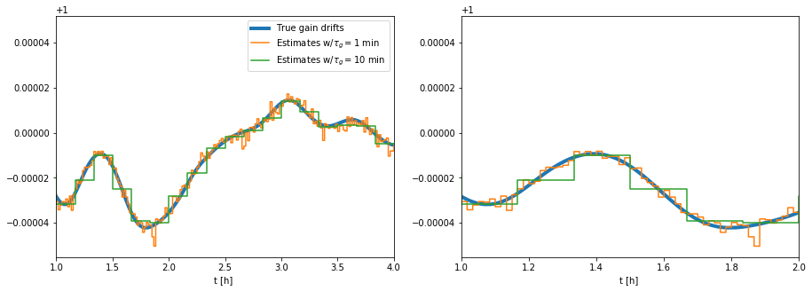

```python
folder = '/Users/peppe/work/satellite_sims/drifting_gain/monopole/'
obs=12.

tau1=60; fs=20;
tau10 =tau1*10.
g=pl.load(folder+ 'gains_6h.npy')[0,:] ;
ge1=pl.load(folder+ 'gains_coeff_1min.npy')[:,0]
ge10 = pl.load(folder+ 'gains_coeff_10min.npy')[:,0]
te1 = ( (pl.arange(len( ge1) ) )  *tau1  + (tau1/2) ) /3600.
te10 = ( (pl.arange(len( ge10) ) )  *tau10  + (tau10/2) ) /3600.

t = pl.arange(len(g) )/fs/3600.
print ( te1.shape)
pl.figure(figsize=(15,5))
pl.subplot(121)
pl.xlabel('t [h] ')
pl.plot(t,g  +1, lw=4 , label='True gain drifts ' ) ;
pl.step(te1,ge1 , where='mid' , label=r'Estimates w/$\tau_g =1$ min ');
pl.step(te10,ge10 , where='mid', label=r'Estimates w/$\tau_g =10$ min ')
pl.xlim([1,4])
pl.legend()
pl.subplot(122)
pl.xlabel('t [h] ')

pl.plot(t,g  +1 , lw=4 ) ; pl.step(te1,ge1 , where='mid' ); pl.step(te10,ge10 , where='mid')
pl.xlim([1,2])
```

```python
import scipy.stats as spt
```

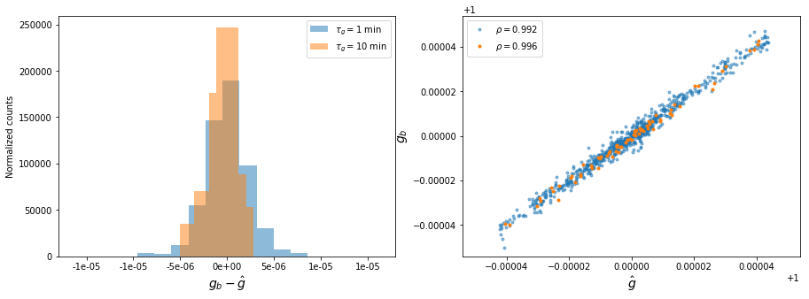

```python
pl.figure(figsize=(15,5))

gb1 =bin_gains (tau1, fs ,obs,  g+1 )
gb10  =bin_gains (tau10, fs ,obs,  g+1 )
pl.subplot(121)
pl.hist(ge1-gb1, alpha=.5, normed=True, label=r'$\tau_g =1$ min ' )
pl.hist(ge10-gb10, alpha=.5, normed=True , label=r'$\tau_g =10$ min ')

pl.xlim([ -(gb1 ).std(), (gb1 ).std()] )
pl.xlabel(r'$g_b -\hat{g} $', fontsize=14)
pl.ylabel('Normalized counts')
pl.legend()

import  matplotlib.ticker as mtick
pl.gca().xaxis.set_major_formatter(mtick.FormatStrFormatter('%.0e'))
r1= spt.linregress(ge1, gb1)[2]
r10= spt.linregress(ge10, gb10)[2]

pl.subplot(122)
pl.plot(gb1,ge1 , '. ',   alpha=.5 , label=r'$\rho =%.3f$'%r1  )
pl.plot(gb10,ge10, '.', label=r'$\rho =%.3f$'%r10 )
pl.xlim([ 1 -3*(gb1 ).std(),1+ 3*(gb1 ).std()] )
pl.ylim([1 -3* (gb1 ).std(), 1+ 3* (gb1 ).std()] )
pl.ylabel(r'$g_b$', fontsize=14)
pl.xlabel(r'$\hat{g} $', fontsize=14)
pl.legend()
```

**Fig2** (left) ( blue bins) histogram of the differences between the true gain drifts, $g_b$ (binned every minute) and the gain estimates $\hat{g} $. (orange bins) differences with a longer time scale, i.e. $10 $ min. (right) scatter plots of $g_b$ vs. $\hat{g} $, the linear correlation coefficient $\rho$ is reported in the legend. Notice that for a longer time scale we have less scattered points, as one intuitively can expect.

```python
dri =pl.load(folder+'drifttod_6h.npy')
sig=pl.load(folder+'signaltod_6h.npy')

mit1=pl.load(folder+'mittod_60_6h.npy')
mit10=pl.load(folder+'mittod_600_6h.npy')
from scipy.signal import periodogram

diffd = (dri[0,:] -dri[1,:])/2.

sumd = (dri[0,:] +dri[1,:])/2.
diffm1 = (mit1[0,:] -mit1[1,:])/2.
summ1 = (mit1[0,:] +mit1[1,:])/2.
diffm10 = (mit10[0,:] -mit10[1,:])/2.
summ10 = (mit10[0,:] +mit10[1,:])/2.


sums = (dri[0,:] +sig[1,:])/2.
f,psums = periodogram(sums , fs=fs, scaling='density')

f,psumd = periodogram(sumd , fs=fs, scaling='density'); f,pdifd = periodogram(diffd , fs=fs, scaling='density');
f,psumm1 = periodogram(summ1, fs=fs, scaling='density'); f,pdifm1 = periodogram(diffm1 , fs=fs, scaling='density');
f,psumm10 = periodogram(summ10, fs=fs, scaling='density'); f,pdifm10 = periodogram(diffm10 , fs=fs, scaling='density');
```

```
(1e-14, 0.01)
```

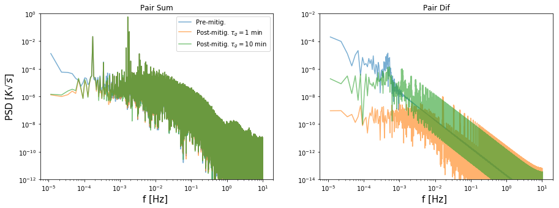

```python
pl.figure(figsize=(15,5))
pl.subplot(121)
pl.title('Pair Sum')
pl.ylabel('PSD ['+r'$K \sqrt{s}$]', fontsize=15)
pl.xlabel('f [Hz] ', fontsize=15);

pl.loglog(f, psumd, alpha=.6, label ='Pre-mitig. ')

pl.loglog(f, psumm1, alpha=.6, label ='Post-mitig. '+r'$\tau_g =1$ min ')
pl.loglog(f, psumm10, alpha=.6, label ='Post-mitig. 'r'$\tau_g =10$ min ')
#pl.loglog(f[1::10000 ], psums[1::10000 ],'k--', alpha=.4 )
pl.legend()
pl.ylim([1e-12,1])
pl.subplot(122)
pl.title('Pair Dif')

pl.loglog(f, pdifd, alpha=.6)

pl.loglog(f, pdifm1, alpha=.6)
pl.loglog(f, pdifm10, alpha=.6)
pl.xlabel('f [Hz] ', fontsize=15);
pl.ylim([1e-14,1e-2])
```